# LMA-with age and work_type, exlude self-care difficulty and disability

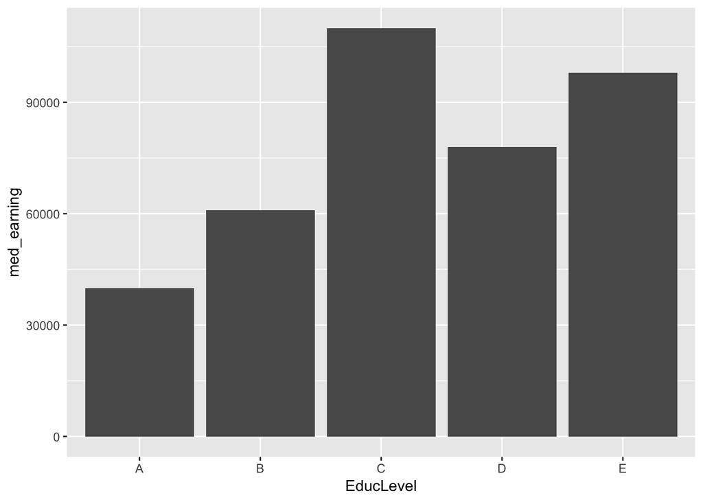

- The histogram graph shows the relationship between educational level and wages of our sample data. From the graph, we can tell that people whose education degree is no higher than high school earn least in the group; people with professional degree earn most money compared to other groups.

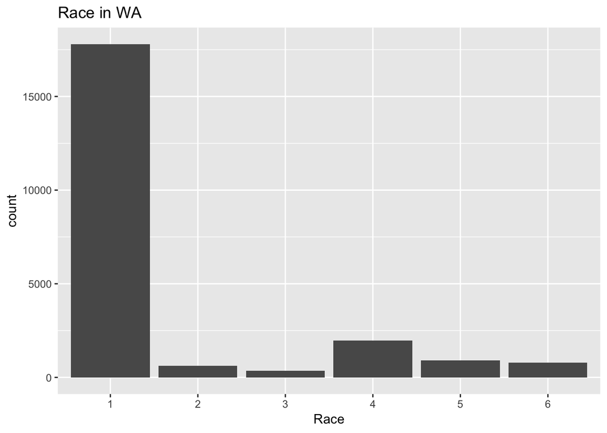

- From the graph, we can see that the majority of people in WA are white; the second largest group is Asian (alone) group; there are few Alaska Native or American Indian in WA.

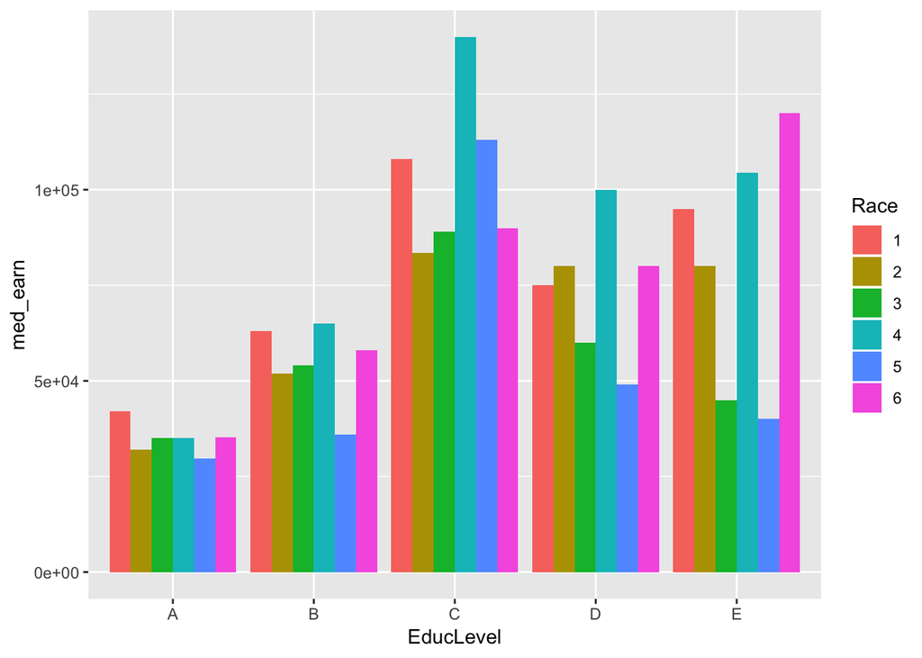

- The graph shows the relationship between wages, educational level, and races.
- We still can find that people with professional degrees earns the most.
- Different races have different advantages in earning among the 5 education levels.